# Pravdepodobnost a statistika

Cviceni 5

Alena Cernikova

2025-10-27

### Nacteni dat a knihoven

```r
# vyber hodnot z databaze diamonds
library(ggplot2)
data(diamonds)
set.seed(123)
diam <- diamonds[sample(nrow(diamonds), 200), ]

library(DescTools)
  # knihovna s popisnymi statistikami
#library(TeachingDemos)
  # knihovna s vyukovymi udelatky
```

### Useknuty prumer

Spoctete useknuty prumer pro promennou table

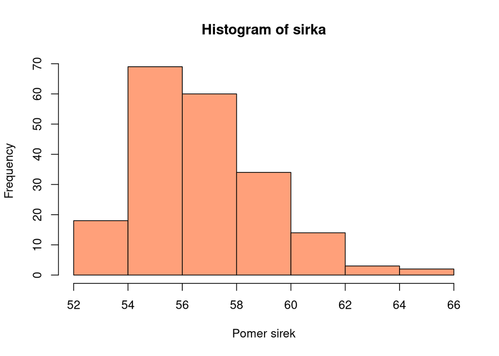

```r
sirka <- diam$table
  # promenna pro pomer sirek
hist(sirka, col = "lightsalmon", xlab = "Pomer sirek")
```

Spoctete useknuty prumer: - na kazde strane useknete 10% pozorovani - useknete vsechny hodnoty vetsi nez 60

```r
cat("Useknuty prumer, 10% useknutych hodnot z kazde strany", "\n")
```

```
## Useknuty prumer, 10% useknutych hodnot z kazde strany
```

```r
mean(sirka, trim = 0.1)
```

```
## [1] 57.0875
```

```r
  # parametr trim rika, jaky dil dat mam useknout z kazde strany
cat("\n", "\n")
```

```r
cat("Pocet hodnot vetsich nez 60", "\n")
```

```
## Pocet hodnot vetsich nez 60
```

```r
(pocet <- sum(sirka > 60))
```

```
## [1] 19
```

```r
cat("Procento hodnot vetsich nez 60", "\n")
```

```
## Procento hodnot vetsich nez 60
```

```r
(proc <- pocet/length(sirka))
```

```
## [1] 0.095
```

```r
cat("Useknuty prumer, hodnot vetsich nez 60", "\n")
```

```
## Useknuty prumer, hodnot vetsich nez 60
```

```r
mean(sirka, trim = proc)
```

```
## [1] 57.09259
```

```r
cat("\n", "\n")
```

```r
cat("Klasicky prumer", "\n")
```

```
## Klasicky prumer
```

```r
mean(sirka)
```

```
## [1] 57.2495
```

Spoctete useknuty prumer hloubky diamantu tak, abyste: – usekli odlehle hodnoty – usekli vsechny hodnoty mensi nez 60 a vetsi nez 64

Spoctete useknuty prumer promenne cena tak, abyste neuvazovali hodnoty vetsi nez 10000.

Useknete vzdy stejny pocet hodnot zleva jako zprava

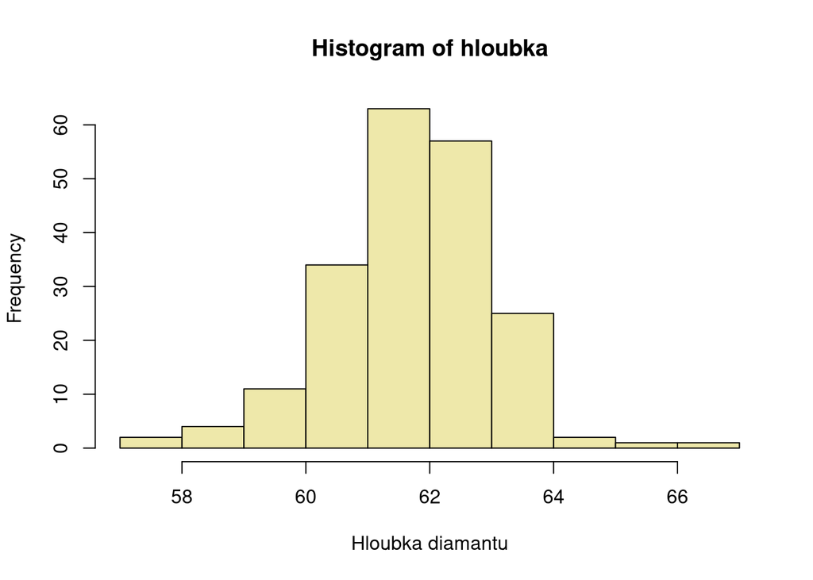

```r
hloubka <- diam$depth
hist(hloubka, col = "palegoldenrod", xlab = "Hloubka diamantu")
```

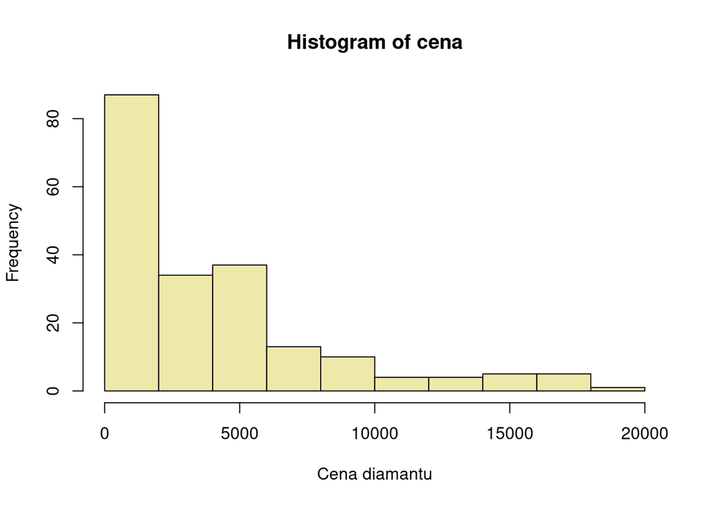

```r
cena <- diam$price
hist(cena, col = "palegoldenrod", xlab = "Cena diamantu")
```

Robustni odhady charakteristik tvaru rozdeleni Pro promennou hloubka

```r
# kvartilovy koeficient sikmosti (Bowley)
Q1 <- quantile(hloubka,0.25)
Q3 <- quantile(hloubka,0.75)
cat("Kvartilovy koeficient sikmosti", "\n")
```

```
## Kvartilovy koeficient sikmosti
```

```r
(Q3 + Q1 - 2*median(hloubka))/(Q3 - Q1)
```

```
##    75%
## -0.125
```

```r
  # v knihovne reflimR existuje funkce bowley, ktera index spocita
  # porovnejte s klasickou sikmosti
  cat("Klasicka sikmost", "\n")
```

```
## Klasicka sikmost
```

```r
  Skew(hloubka)
```

```
## [1] -0.1572776
```

```r
cat("\n", "\n")
```

```r
# oktilovy koeficient spicatosti (Moorse)
Q18 <- quantile(hloubka, 1/8)
Q28 <- quantile(hloubka, 2/8)
Q38 <- quantile(hloubka, 3/8)
Q48 <- quantile(hloubka, 4/8)
Q58 <- quantile(hloubka, 5/8)
Q68 <- quantile(hloubka, 6/8)
Q78 <- quantile(hloubka, 7/8)
cat("Oktilovy koeficient spicatosti", "\n")
```

```
## Oktilovy koeficient spicatosti
```

```r
((Q78 - Q58) + (Q38 - Q18))/(Q68 - Q28)
```

```
##  87.5%
## 1.4375
```

```r
  # porovnejte s klasickou spicatosti
  cat("Klasicka spicatost", "\n")
```

```
## Klasicka spicatost
```

```r
  Kurt(hloubka)
```

```
## [1] 1.036979
```

Porovnejte robustni a klasicke charakteristiky tvaru rozdeleni pro pomer sirek a cenu

```r
sirka <- diam$table
cena <- diam$price
```

### Vztah dvou promennych

Pro popsani vztahu dvou kategorickych promennych se pouziva kontingencni tabulka Souvisi spolu kvalita rezu a barva kamene? (promenne cut a color)

```r
rez <- diam$cut
barva <- diam$color

cat("Absolutni cetnosti obou promennych", "\n")
```

```
## Absolutni cetnosti obou promennych
```

```r
cat("Kvalita rezu", "\n")
```

```
## Kvalita rezu
```

```r
cat("\n", "\n")
```

```r
table(rez)
```

```
## rez
##      Fair      Good Very Good   Premium     Ideal
##         4        18        51        47        80
```

```r
cat("Barva diamantu", "\n")
```

```
## Barva diamantu
```

```r
table(barva)
```

```
## barva
##  D  E  F  G  H  I  J
## 19 33 49 36 35 16 12
```

Popis vzajemneho vztahu promennych

```r
cat("Tabulka absolutnich cetnosti", "\n")
```

```
## Tabulka absolutnich cetnosti
```

```r
(tab <- table(rez, barva))
```

```
##            barva
## rez          D  E  F  G  H  I  J
##   Fair       1  0  1  1  1  0  0
##   Good       3  3  7  2  2  0  1
##   Very Good  6  9 17  6  8  3  2
##   Premium    2  5 11  9 10  5  5
##   Ideal      7 16 13 18 14  8  4
```

```r
# mozna lepe videt z relativnich cetnosti
cat("\n", "\n")
```

```r
cat("Tabulkove relativni cetnosti", "\n")
```

```
## Tabulkove relativni cetnosti
```

```r
addmargins(round(prop.table(tab), 4))
```

```
##            barva
## rez             D     E     F     G     H     I     J   Sum
##   Fair      0.005 0.000 0.005 0.005 0.005 0.000 0.000 0.020
##   Good      0.015 0.015 0.035 0.010 0.010 0.000 0.005 0.090
##   Very Good 0.030 0.045 0.085 0.030 0.040 0.015 0.010 0.255
##   Premium   0.010 0.025 0.055 0.045 0.050 0.025 0.025 0.235
##   Ideal     0.035 0.080 0.065 0.090 0.070 0.040 0.020 0.400
##   Sum       0.095 0.165 0.245 0.180 0.175 0.080 0.060 1.000
```

```r
cat("\n", "\n")
```

```r
cat("Radkove relativni cetnosti", "\n")
```

```
## Radkove relativni cetnosti
```

```r
addmargins(round(prop.table(tab, 1), 4))
```

```
##            barva
## rez              D      E      F      G      H      I      J    Sum
##   Fair      0.2500 0.0000 0.2500 0.2500 0.2500 0.0000 0.0000 1.0000
##   Good      0.1667 0.1667 0.3889 0.1111 0.1111 0.0000 0.0556 1.0001
##   Very Good 0.1176 0.1765 0.3333 0.1176 0.1569 0.0588 0.0392 0.9999
##   Premium   0.0426 0.1064 0.2340 0.1915 0.2128 0.1064 0.1064 1.0001
##   Ideal     0.0875 0.2000 0.1625 0.2250 0.1750 0.1000 0.0500 1.0000
##   Sum       0.6644 0.6496 1.3687 0.8952 0.9058 0.2652 0.2512 5.0001
```

```r
cat("\n", "\n")
```

```r
cat("Sloupcove relativni cetnosti", "\n")
```

```
## Sloupcove relativni cetnosti
```

```r
addmargins(round(prop.table(tab, 2), 4))
```

```
##            barva
## rez              D      E      F      G      H      I      J    Sum
##   Fair      0.0526 0.0000 0.0204 0.0278 0.0286 0.0000 0.0000 0.1294
##   Good      0.1579 0.0909 0.1429 0.0556 0.0571 0.0000 0.0833 0.5877
##   Very Good 0.3158 0.2727 0.3469 0.1667 0.2286 0.1875 0.1667 1.6849
##   Premium   0.1053 0.1515 0.2245 0.2500 0.2857 0.3125 0.4167 1.7462
##   Ideal     0.3684 0.4848 0.2653 0.5000 0.4000 0.5000 0.3333 2.8518
##   Sum       1.0000 0.9999 1.0000 1.0001 1.0000 1.0000 1.0000 7.0000
```

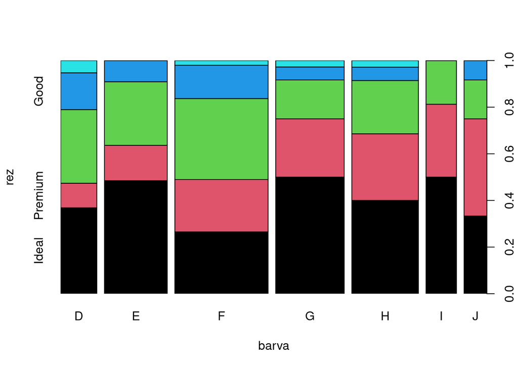

```r
  # ktery typ relativnich cetnosti se pro popis zavislosti hodi nejvic?

plot(rez ~ barva, col = 1:5)
```

```r
  # Jak byste vztah popsali?
```

Souvisi spolu barva a “cistota” kamene? (promenne color a clarity)

```r
cistota <- diam$clarity
barva <- diam$color
```

Vztah dvou ciselnych promennych popisujeme pomoci bodoveho (rozptyloveho) grafu, korelacniho koeficientu, korelacni tabulky My se zamerime na popis linearniho vztahu

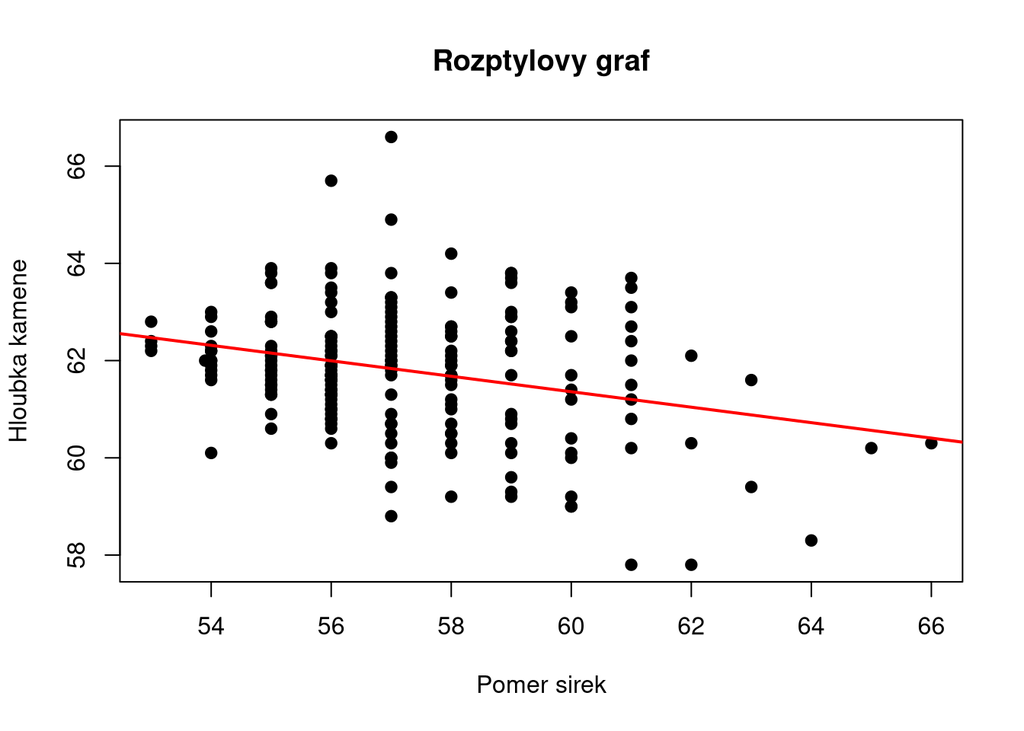

```r
# Jaky je vztah mezi promennymi hloubka a pomer sirek?
hloubka <- diam$depth
sirka <- diam$table
plot(hloubka ~ sirka, pch = 19, main = "Rozptylovy graf", xlab = "Pomer sirek", ylab="Hloubka kamene")
  # Co z grafu vidite?
  abline(lm(hloubka ~ sirka), col = "red", lwd = 2)
```

```r
    # prikresli do grafu primku linearni zavislosti

cat("Kovariance = ", cov(hloubka, sirka, use = "complete.obs"), "\n")
```

```
## Kovariance =  -0.8519867
```

```r
  # co Vam rika kovariance
cat("Korelace = ", cor(hloubka, sirka, use = "complete.obs"), "\n")
```

```
## Korelace =  -0.2790496
```

```r
  # a co korelace

# A co je korelacni tabulka?
hloubka.c <- factor(ifelse(hloubka <= 60, '<60', ifelse(hloubka <= 62, '60-62',
                    ifelse(hloubka <= 64, '62-64', ifelse(hloubka <= 66, '64-66',
                    ifelse(hloubka <= 68, '66-68', '>68'))))),
                    levels=c("<60", "60-62", "62-64", "64-66", "66-68", ">68"))
sirka.c <- factor(ifelse(sirka <= 54, '<54', ifelse(sirka <= 56, '54-56',
                  ifelse(sirka <= 58, '56-58', ifelse(sirka <= 60, '58-60',
                  ifelse(sirka <= 62, '60-62', ifelse(sirka <= 64, '62-64', '>64')))))),
                  levels=c("<54","54-56","56-58","58-60", "60-62", "62-64", ">64"))
cat("\n", "Korelacni tabulka", "\n")
```

```
##
##  Korelacni tabulka
```

```r
table(hloubka.c, sirka.c)
```

```
##          sirka.c
## hloubka.c <54 54-56 56-58 58-60 60-62 62-64 >64
##     <60     0     0     6     7     2     2   0
##     60-62   8    41    28    11     6     1   2
##     62-64  10    27    23    16     6     0   0
##     64-66   0     1     2     0     0     0   0
##     66-68   0     0     1     0     0     0   0
##     >68     0     0     0     0     0     0   0
```

Popiste vzajemny vztah hmotnosti a ceny kamene

```r
hmot <- diam$carat
cena <- diam$price
```

### Hodnoceni normality

Jak zjistit, zda promenna ma ci nema normalni / Gaussovo rozdeleni

Muze mit sirka kamene normalni rozdeleni?

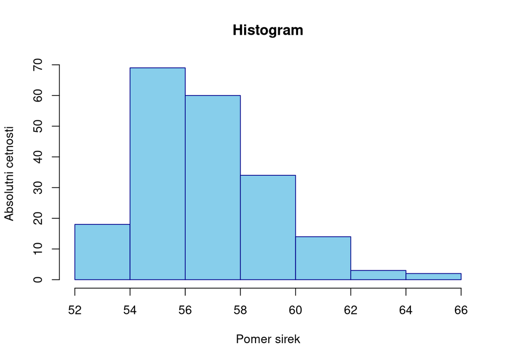

```r
sirka <- diam$table

# histogram
hist(sirka, main="Histogram", xlab = "Pomer sirek", ylab = "Absolutni cetnosti",
    col = "skyblue", border = "darkblue")
```

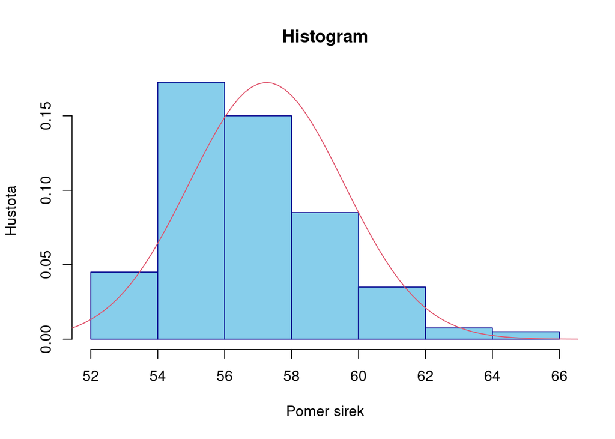

```r
  # s hustotou normalniho rozdeleni
  hist(sirka ,main = "Histogram", xlab = "Pomer sirek", ylab = "Hustota",
    col = "skyblue", border = "darkblue", freq = F)
    # je treba vykreslit histogram prepocteny na hustotu
  lines(x <- seq(50, 140, by = 0.2), dnorm(x, mean(sirka), sd(sirka)), col = 2)
```

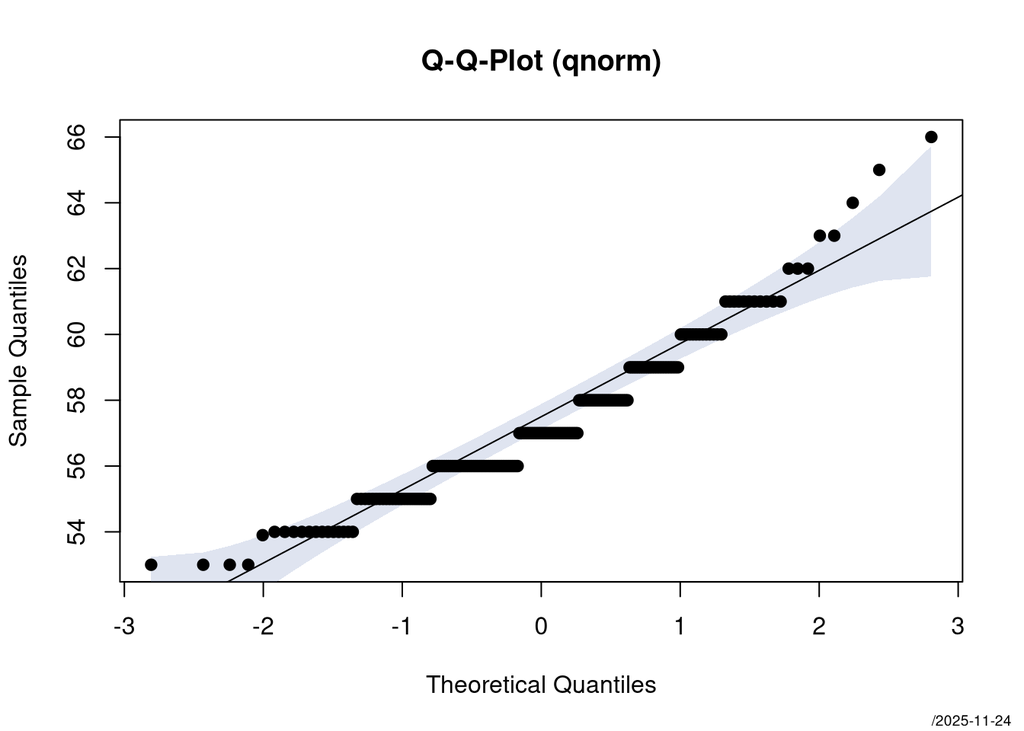

```r
    # jak sloupce odpovidaji Gaussove krivce?

# Graficky test: Q-Q plot - Quantile Comparison plot
PlotQQ(sirka, pch = 19)
```

```r
  # pokud body lezi na primce, odpovida to normalnimu rozdeleni
  # zde body lezi na oblouku, coz znaci sesikmene rozdeleni

# Ciselne charakteristiky tvaru rozdeleni
cat("Sikmost =", Skew(sirka), "\n")
```

```
## Sikmost = 0.7894906
```

```r
  # kladna sikmost (vetsi nez 0.3) znaci sesikmeni doprava
cat("Spicatost =", Kurt(sirka), "\n")
```

```
## Spicatost = 0.8350742
```

```r
  # kladna spicatost (vetsi nez 0.5) znaci spicatejsi rozdeleni nez normalni (dlouhy chvost)

# Pro "rozumne" velka data (od 50 do cca 300 pozorovani)
#   je mozne vypocitat i ciselny test normality
# Testujeme
#   H0: data maji normalni rozdeleni vs. H1: data nemaji normalni rozdeleni
shapiro.test(sirka)
```

```
##
##  Shapiro-Wilk normality test
##
## data:  sirka
## W = 0.94727, p-value = 1.038e-06
```

```r
  # p-hodnota 1.038e-06 < alfa 0.05 => H0 zamitame
  # data nemaji  rozdeleni
  LillieTest(sirka)
```

```
##
##  Lilliefors (Kolmogorov-Smirnov) normality test
##
## data:  sirka
## D = 0.14792, p-value = 1.689e-11
```

```r
  AndersonDarlingTest(sirka, "pnorm", mean = mean(sirka), sd = sd(sirka))
```

```
##
##  Anderson-Darling test of goodness-of-fit
##  Null hypothesis: Normal distribution
##  with parameters mean = 57.249, sd = 2.315
##
## data:  sirka
## An = 3.2924, p-value = 0.01953
```

```r
    # testu existuje vice
```

Otestujte normalitu promennych depth (hloubka kamene) a carat (hmotnost kamene).

```r
hloubka <- diam$depth
hmot <- diam$carat
```